# Compartmental models

Ravi Brenner

Notes and code following chapter 2 of Modeling Infectious Diseases in Humans and Animals by Matt J. Keeling and Pejman Rohani.

```r
library(tidyverse)
library(deSolve)
```

# 1 Building up compartmental models

Unfortunately, this chapter jumps right in to some confusing terminology and derivations. I will deal with each of these issues in turn.

## 1.1 Model structure

Basically, capital letters are used to represent different compartments, and differential equations are solved to get deterministic solutions. In the most intuitive (and famous) SIR model, S = Susceptible, I = Infected/Infectious, and R = Recovered. For a closed population of size N, we assume S + I + R = N. People move from S to I and from I to R, and that’s it. How fast people move from S to I depends on how many people are in S and I.

The model equations look like this (we will derive these next):

$\frac{dS}{dt} = -\beta SI$

$\frac{dI}{dt} = \beta SI - \gamma I$

$\frac{dR}{dt} = \gamma I$

## 1.2 Deriving the parameters

So for the SIR model, there are 2 terms to worry about:

1. The S–>I “transmission” term
2. the I–>R recovery term

(note that R is just 1 - S - I)

2. is actually fairly straightforward. If someone is infectious for *t* period of time, then their time spend infectious is equal to $1/t = \gamma$. We call $\gamma$ the recovery rate.
3. is more complicated, but it works like this. The rate that people get infected depends on the number of contacts between susceptible and infectious people, and the per-person probability of acquiring infection, given contact (this is often called the force of infection, $\lambda$). Here’s where it gets complicated.

### 1.2.1 Density dependent and frequency dependent transmission

I found Keeling and Rohani’s explanation of this very confusing. But [this](https://parasiteecology.wordpress.com/2013/10/17/density-dependent-vs-frequency-dependent-disease-transmission/) blog post was very helpful in helping me understand.

In density-dependent (DD) transmission, the contact rate between S and I depends on the density within the physical space. Think of a crowded subway car and a respiratory disease.

In frequency dependent (FD) transmission, the contact rate does not depend on population density. Think of a crowded subway car and an STI. One is not more likely to contract an STI on a subway car if it is full of more or less people.

The transmission terms look like this:

$DD: \frac{dI}{dt} = \lambda S$

$FD: \frac{dI}{dt} = \lambda' S$

And those $\lambda$ values look like this:

$DD: \lambda = c * v * I/N$

$FD: \lambda' = c' * v * I/N$

So lambda, the force of infection, is the product of 1) the probability/rate that a contact happens between individuals (c or c’), 2) the probability/rate that one of those contacts is infected (I/N), and 3) the probability/rate that a contact between an S and an I individual results in transmission (v). You can see that the only thing that changes is c/c’, the probability/rate that people come into contact (think of the subway example again).

In DD, that contact rate will increase as some function of the density (people/area, or N/A) of people in the space. So we can say that $c = k * N/A$. In theory this could be nonlinear too.

In FD, that contact rate will be constant, so $c'=k$.

Putting this together, we get

$DD: \frac{dI}{dt} = cv\frac{I}{N}S = k\frac{N}{A}v\frac{I}{N}S = k\frac{1}{A}vIS$

$FD: \frac{dI}{dt} = c'v\frac{I}{N}S = kv\frac{I}{N}S$

If we take A to be a constant (which can be an OK assumption if we’re modeling a consistent area over time), we can combine all constant terms into one:

$DD: \frac{dI}{dt} = \beta SI$

$FD: \frac{dI}{dt} = \beta' SI/N$

There are some more possible complications here, but this is good for now.

One note is that K&R use S, I, and R to represent proportions, and X, Y, and Z to represent the numbers of people in each compartment. In fact in their terminology we should really have these terms:

$DD: \frac{dY}{dt} = \beta XY$

$FD: \frac{dY}{dt} = \beta' XY/N$

This may seem like overkill detail, but these details become important when population size changes (e.g. with birth and death or migration) or if we are trying to model something across a range of population sizes.

# 2 SIR model without demography

Returning to the basic model (note this is FD). The full terms are:

$\frac{dS}{dt} = -\beta SI$

$\frac{dI}{dt} = \beta SI - \gamma I$

$\frac{dR}{dt} = \gamma I$

$\beta$ here is the number of people infected per unit time per infected person.

$\gamma$ is the recovery rate, and $1/\gamma$ is the average infectious period.

Note that S + I + R must = 1

If we focus on $\frac{dI}{dt} = I (\beta S - \gamma)$, some interesting things pop out. If $S(0) < \frac{\gamma}{\beta}$, dI/dt is < 0 and infection “dies out.” Another way of thinking about this is that if $S(0) > \frac{\gamma}{\beta}$, the infection will grow. We can think of $\frac{\gamma}{\beta}$ as the removal rate from the infectious compartment. The inverse is called the basic reproductive ratio, $R_0 = \frac{\beta}{\gamma}$ (“R naught” or “R not”), defined as the average number of secondary cases arising from an average primary case in an entirely susceptible population.

In a closed population, a disease can only grow if the fraction of susceptibles S is greater than $1/R_0$.

We can create this model in R:

```r
sirmod <- function(t, state, params){
  # pull listed inputs into environment as names variables
  with(as.list(c(state,params)),{
    # define equations
      dS = -beta * S * I
      dI = beta*S*I - gamma*I
      dR = gamma * I

      list(c(dS,dI,dR))
  })
}

times = seq(0,26, by=1/10) #26 weeks, in discrete units
state = c(S = 0.999, I = 0.001, R = 0) # initial state values
params = c(beta = 2, gamma = 1/2, N = 1) # parameters
# beta = 1 means each infected can infect 1 people per week
# gamma = 1/2 means the infectious period is 2 weeks

sir_out <- ode(y = state, t = times, func = sirmod, parms = params) |>
  as_tibble() |>
  mutate(across(everything(), as.numeric))
```

Plot model

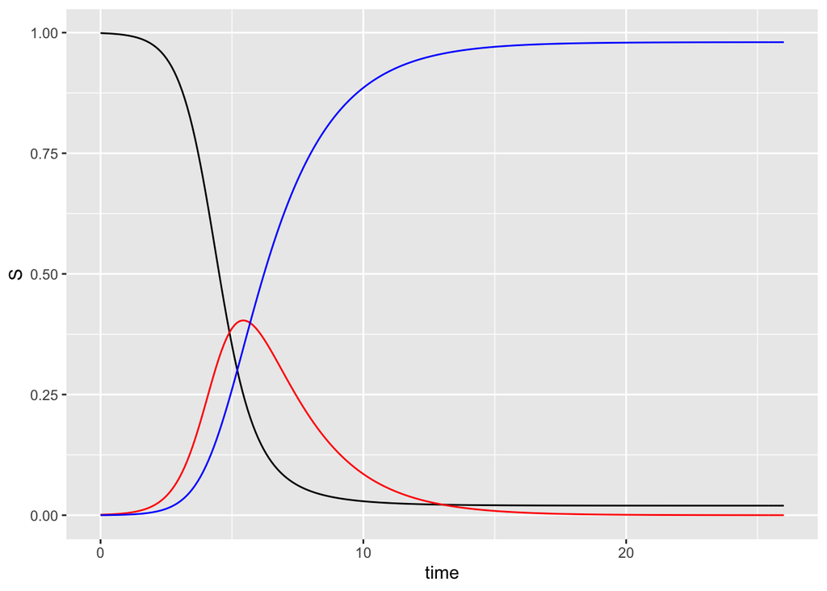

```r
sir_out |>
  ggplot(aes(x = time)) +
  geom_line(aes(y = S)) +
  geom_line(aes(y = I),color = "red") +
  geom_line(aes(y = R),color = "blue")
```

Final epidemic size

```r
final_size = rootSolve::runsteady(y=state,times=c(0,100), func=sirmod, parms=params)
final_size$y
```

```
##            S            I            R
## 1.980853e-02 2.270720e-08 9.801914e-01
```

```r
#alternatively...assuming time is long enough
sir_out[nrow(sir_out),]
```

| time | S | I | R |
| --- | --- | --- | --- |
| 26 | 0.01981067 | 5.593283e-05 | 0.9801334 |

## 2.1 Epidemic Burnout

Some interesting math here, but the point to flag is:

The chain of transmission eventually breaks due to the decline in infectives, not due to a complete lack of susceptibles.

In fact, there will (almost always) remain some proportion of susceptibles who are uninfected at the end.

# 3 SIR model with demography

Add in a mortality rate $\mu$, with average lifespan equal to $1/\mu$.

Here, we are also assuming that $\mu$ is the population’s birth rate (hence the positive $\mu$ in the dS equation)

$\frac{dS}{dt} = \mu -\beta SI - \mu S$

$\frac{dI}{dt} = \beta SI - \gamma I - \mu I$

$\frac{dR}{dt} = \gamma I - \mu R$

We again rearrange $\frac{dI}{dt} = I(\beta S - (\gamma + \mu))$, to find that $R_0 = \frac{\beta}{\gamma + \mu}$

Note S + I + R here must still be = 1

```r
sir_demo_mod <- function(t, state, params){
  # pull listed inputs into environment as names variables
  with(as.list(c(state,params)),{
    # define equations
      dS = mu -(beta * S * I ) - mu*S
      dI = (beta*S*I) - gamma*I - mu * I
      dR = gamma * I - mu*R

      # dead = mu*S + mu*I + mu*R
      # born = mu*N

      list(c(dS,dI,dR))
  })
}

times = seq(0,26, by=1/10)
state = c(S = 0.999, I = 0.001, R = 0) # initial state values
params = c(beta = 2, gamma = 1/2, mu = 0.0003, N = 1) # parameters

sir_demo_out <- ode(y = state, t = times, func = sir_demo_mod, parms = params) |>
  as_tibble() |>
  mutate(across(everything(), as.numeric))
```

plot model

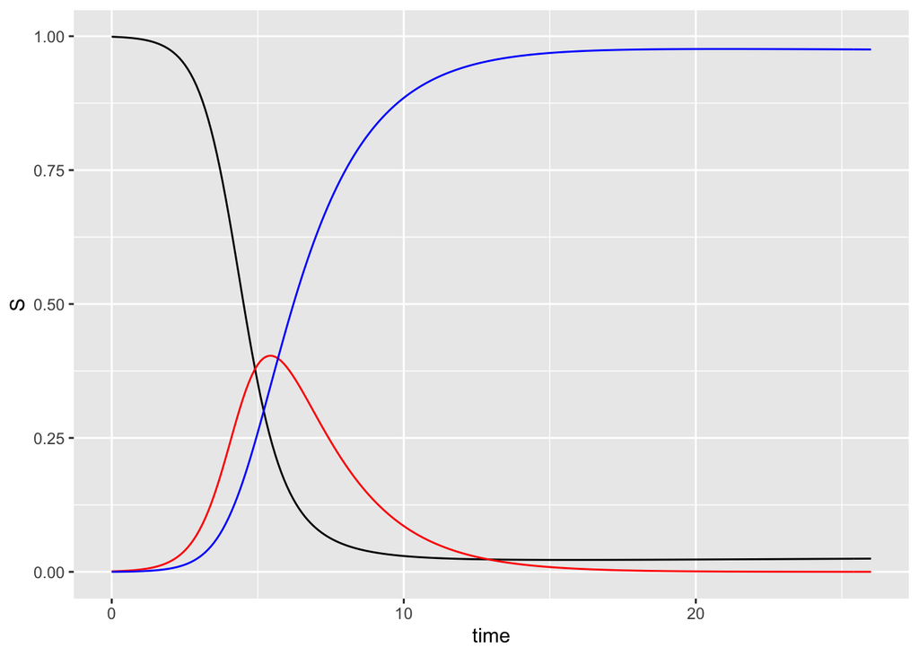

```r
sir_demo_out |>
  ggplot(aes(x = time)) +
  geom_line(aes(y = S)) +
  geom_line(aes(y = I),color = "red") +
  geom_line(aes(y = R),color = "blue")
```

## 3.1 Endemic equilibrium

What happens at equilibrium when dS = dI = dR = 0?

There is a disease free equilibrium when S = 1, I = R = 0.

In endemic equilibrium, we find $S^{*}= (\gamma + \mu) / \beta = 1/R_0$

“In the SIR model with births and deaths, the endemic equilibrium is characterized by the fraction of susceptibles in the population being the inverse of $R_0$.”

Can plug that in to find that $I^{*} = \frac{\mu}{\gamma + \mu}(1-\frac{1}{R_0}) = \frac{\mu}{\beta}(R_0 -1)$. (I think there is typo in K&R here).

($R^{*}$ is just $1-S^{*} -I^{*}$ here)

This requires $R_0 > 1$ for endemic equilibrium, otherwise the disease-free equilibrium will hold.

```r
r0 <- params["beta"] / (params["gamma"] + params["mu"])
I_star = (params["mu"] / params["beta"]) * (r0-1)
r0
```

```
##     beta
## 3.997601
```

```r
I_star
```

```
##           mu
## 0.0004496402
```

## 3.2 Oscillations

K&R discuss precisely *how* equilibrium is approached. It turns out is is a damped oscillator, bouncing up and down but gradually closing in on the equilibrium value. They note “the period of oscillations changes with the transmission rate ($\beta$) and the infectious period ($1/\gamma$). We note that (relative to the infectious period) the period of oscillations becomes longer as the reproductive ratio approaches one; this is also associated with a slower convergence toward the equilibrium.”

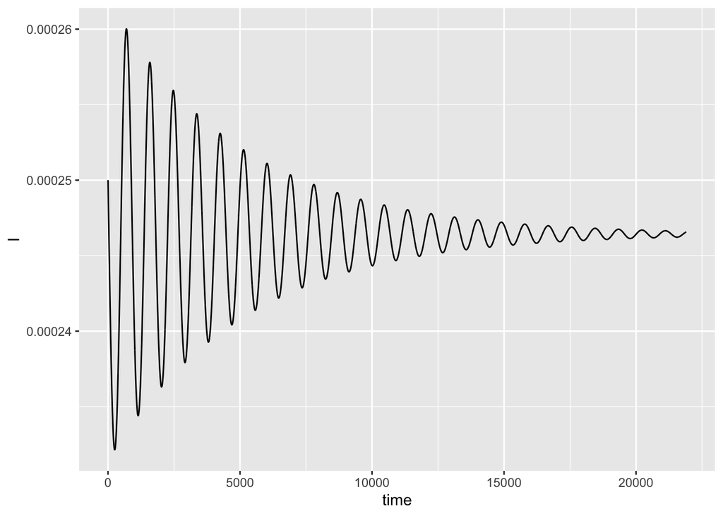

```r
times = seq(0,60*365, by=1)
state = c(S = 0.1, I = 2.5e-4, R = 1-0.1-2.5e-4) # initial state values
params = c(beta = 520/365, gamma = 1/7, mu = 1/(70*365), N = 1) # parameters

sir_demo_out <- ode(y = state, t = times, func = sir_demo_mod, parms = params) |>
  as_tibble() |>
  mutate(across(everything(), as.numeric))

sir_demo_out |>
  ggplot(aes(x = time, y = I)) +
  geom_line()
```

There’s some linear algebra involved in calculating the periods of the oscillations. But it turns out that it can be approximated as $T\approx2\pi\sqrt{AG}, A = \frac{1}{\mu(R_0-1)}, G = \frac{1}{\mu+\gamma}$.

Where A is the average age at infection (more in a minute) and G determines the average period of infection.

```r
r0 <- params["beta"] / (params["gamma"] + params["mu"])
a = 1/(params["mu"]*(r0-1))
g = 1/(params["gamma"] + params["mu"])
t = 2*pi*sqrt(a*g);t/365
```

```
##       mu
## 2.430406
```

## 3.3 Average age of infection

Basically, we start from the model equation $\frac{dS}{dt} = \mu -\beta SI - \mu S$. If $\mu$ is small, then the average time spent in S is $1/\beta I^{*}$ at equilibrium. Substituting in $I^{*} = \frac{\mu}{\beta}(R_0 -1)$, we find that $A \approx \frac{1}{\mu(R_0-1)}$.

Can rewrite this as $R_0 -1 \approx L/A$ with L=lifespan = 1/mu

```r
age_infex <- 1/(params["mu"]*(r0-1))
age_infex / 365
```

```
##       mu
## 7.803902
```

“The mean age of (first) infection is equal to the average life expectancy of an individual divided by $R_0 −1$.”

# 4 infection induced mortality and SI models

There are multiple possibilities here, and things start to get more complex. I think this is an area where K&R get quite confusing and switch notation up a lot.

We are going to strip the model down to just 2 compartments, S and I, and assume that the only way to leave I is through death from infection (yes this is extreme). The obvious way to do that would do be to add a mortality $m$ term to he dI equation, where $m$ is a per-capita disease induced mortality rate for infected individuals. In practice, it’s easier to consider the probability $\rho$ of an infected individual dying from infection before recovering or dying from other causes.

This changes the dI equation to:

$\frac{dI}{dt} = \beta SI - (\gamma +\mu)I - \frac{\rho}{1-\rho}(\gamma + \mu) I$

With the new term thought of as the per capita disease induced morality rate. We can rearrange this equation a bit:

$\frac{dI}{dt} = \beta SI - \frac{\gamma + \mu}{1-\rho} I$

Note that as $\rho$ goes to 1, R0 drops to 0 (because new infections die almost immediately).

This isn’t so realistic for infections where you die only later in infection, but it is a good starting point.

## 4.1 Mortality throughout infection

Up to now, we have been assuming S, I, and R are proportions and N is constant. Bus as N changes, the dynamics change too. If people are dying from infection, or being born at a different rate than they die, these assumptions need to change. We can now write

$\frac{dS}{dt} = \nu -\beta SI - \mu S$

However this glosses over how N is factored in. How we deal with N depends on whether we’re looking at density or frequency dependent transmission. This is where things get complicated.

### 4.1.1 Density dependent transmission

(Recall that this is like getting the flu on a crowded subway car. The more people in the car, the more likely you are to get the disease)

S->X I->Y R->Z

We now have a new equation, $\frac{dN}{dt}$. In the absence of disease,

$\frac{dN}{dt} = \nu - \mu N \Rightarrow N \rightarrow \nu/ \mu$.

This gives the carrying capacity of the population. When there is no disease, N = S, and I = R = 0.

The other model equations now look like:

$\frac{dX}{dt} = \nu -\beta XY - \mu X$

$\frac{dY}{dt} = \beta XY - \frac{\gamma + \mu}{1-\rho} Y$

$\frac{dZ}{dt} = \gamma Y - \mu Z$

How to calculate $R_0$? Same as before. Consider the dY equation, and recall that $S=X/N$, so $X = NS$:

$Y(\beta X-\frac{\gamma + \mu}{1-\rho}) > 0 \Rightarrow \beta NS -\frac{\gamma + \mu}{1-\rho} > 0$

Rearrange to get

$\beta NS =\frac{\gamma + \mu}{1-\rho} \Rightarrow S^{*} = \frac{\gamma + \mu}{\beta N(1-\rho)}$

And since $R_0 = 1/S^{*}$, we get $R_0 = \frac{\beta (1-\rho) \nu}{(\gamma + \mu)\mu}$ This is similar to $R_0$ we found before, but with a correction term $1-\rho$ that accounts for reduced infectivity due to disease induced mortality, and a tern for the population size.

Note now the endemic equilibrium is:

$X^{*} = \frac{\mu + \gamma}{\beta(1-\rho)} = \frac{\nu}{\mu R_0}$

$Y^{*} = \frac{\mu}{\beta}(R_0-1)$

$Z^{*} = \frac{\gamma}{\beta}(R_0-1)$

$N^{*} = \frac{\nu}{\mu R_0}[1+(1-\rho)(R_0-1)]$

The takeaway here is: “When disease-induced mortality is added to the SIR model with density-dependent transmission, the equilibrium and stability properties simply reflect a change in parameters.”

### 4.1.2 Frequency dependent transmission

Before, we were able to easily switch between the count and proportion and remove N as needed. Now since N is changing though, things get much trickier.

The model equations now:

$\frac{dX}{dt} = \nu -\beta XY/N - \mu X$

$\frac{dY}{dt} = \beta XY/N - \frac{\gamma + \mu}{1-\rho} Y$

$\frac{dZ}{dt} = \gamma Y - \mu Z$

Now, even when population size is reduced, each individual still has the same average number of contacts.

You can find the equilibrium by setting the differential equations equal to 0.

(The algebra here is quite complicated. You can definitely skip over it. I worked through it by hand. Essentially you start by setting the differential equations equal to 0. Get an expression for Z in terms of Y, an expression for X in terms of N, and plug that in to get an expression for Y in terms of N. Now you have expressions for all 3 compartments in terms of N. You can then set N = X + Y + Z and solve for N. Then plug that back in to find the X and Y solutions).

The endemic equilibrium is:

$X^{*} = \frac{\nu(1-\rho)(\gamma + \mu)}{\mu(\beta(1-\rho)-\mu \rho - \gamma \rho)} = \frac{N}{R_0} \Rightarrow S^{*} = \frac{\gamma+\mu}{\beta(1-\rho)} = 1/R_0$

$Y^{*} = \frac{\nu \beta(1-\rho)^2-\nu(\mu + \gamma)(1-\rho)}{(\mu + \gamma)(\beta(1-\rho)-\mu \rho - \gamma \rho)}\Rightarrow I^{*} = \frac{\mu}{\beta(1-\rho)}(R_0 - 1)$

$N^{*} = \frac{\beta \nu(1-\rho)^2}{\mu(\beta(1-\rho)-\mu \rho - \gamma \rho)} = \frac{\nu}{\mu}(\frac{R_0(1-\rho)}{R_0 - \rho})$

Some comments:

“Not surprisingly, infectious diseases with the highest mortalities ($\rho$ close to one) and largest $R_0$ have the greatest impact on the population.”

Although for low mortality levels both mixing assumptions lead to similar results, when the mortality is high the frequency-dependent assumption leads to the largest drop in the total population size. This is because density dependent mixing places a natural damping on transmission, such that as the population size decreases so does the contact rate between individuals, limiting disease spread and reducing disease-induced mortality.

When disease-induced mortality is added to the SIR model with frequency dependent transmission, the equilibrium and stability properties can change substantially, especially if the probability of mortality is high.”

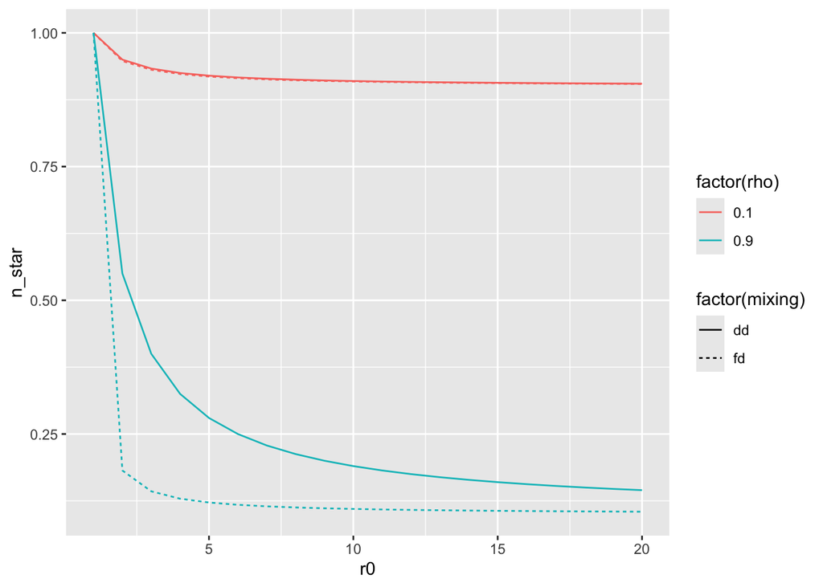

```r
r0 = seq(1,20,1)
rho = c(0.1,0.9)
N_table <- expand_grid(r0,rho,mixing = c("fd","dd")) |>
  mutate(n_star = if_else(mixing == "dd",(1/r0)*(1+(1-rho)*(r0-1)),r0*(1-rho)/(r0-rho)))

N_table |>
  ggplot(aes(x = r0, y = n_star, color = factor(rho),
             linetype = factor(mixing))) +
  geom_line()
```

## 4.2 Mortality late in infection

This is more realistic if we want to consider a situation where mortality occurs toward the end of the infectious period. Basically rather than being removed from $I$ via death from infection, people are removed from $R$ via death from infection.

$\frac{dS}{dt} = \nu -\beta SI -\mu S$

$\frac{dI}{dt} = \beta SI - (\gamma+\mu) I$

$\frac{dR}{dt} = (1-\rho)\gamma I - \mu R$

Here, rho is the probability of an infected individual dying from the disease. Basically, they spend the entire infectious period in the $I$ class, and then instead of moving to recovery, they are just removed from the $R$ class as a death.

$X^{*} = \frac{\nu(\mu+\gamma(1-\rho))}{(\beta -\gamma \rho)\mu}, Y^{*} = \frac{\nu(\beta - \mu - \gamma)}{(\beta -\gamma \rho)(\gamma +\mu)}, R_0 = \frac{\beta \nu }{\mu(\gamma + \mu)} > 1$

“The equilibrium levels of diseases that cause mortality are critically dependent upon whether frequency- or density-dependent transmission is assumed, due to the changes in the total population size that occur. However, we generally find that the endemic equilibrium is feasible and stable as long as $R_0>1$.”

## 4.3 Fatal infections

If infections always kill (which can sometimes be the case), we remove the recovered class and are left with an SI model. The mode of transmission (FD or DD) still matters, but the number of equations simplifies things considerably.

For Frequency-dependent:

$\frac{dX}{dt} = \nu - \beta XY/N - \mu X$

$\frac{dY}{dt} = \beta XY/N - (\gamma + \mu) Y$

where people remain infectious for an average period of time $1/\gamma$.

You can solve to find

$X^{*} = \frac{\nu}{\beta -\gamma}, Y^{*} = \frac{\nu(\beta - \gamma - \mu)}{(\beta - \gamma)(\gamma + \mu)}, R_0 = \frac{\beta}{(\mu + \gamma)} > 1$/

For density dependent:

$\frac{dX}{dt} = \nu - \beta XY - \mu X$

$\frac{dY}{dt} = \beta XY - (\gamma + \mu) Y$

You can solve to find

$X^{*} = \frac{\gamma+\mu}{\beta}, Y^{*} = \frac{\nu}{(\mu + \gamma)} - \frac{\mu}{\beta}, R_0 = \frac{\beta \nu}{(\mu + \gamma)\mu} > 1$

# 5 SIS model (no immunity)

$\frac{dS}{dt} = \gamma I -\beta SI$

$\frac{dI}{dt} = \beta SI - \gamma I$

S + I = 1

Can actually solve these to find that

$I^{*} = (1-1/R_0)$

$S^{*} = 1/R_0$

$R_0 = \beta/\gamma$

As the equilibrium. Basically this means that for a disease that does not lead to long-term immunity, the disease will persist long term in the population if R0 > 1. Basically it will become endemic at a level determined by $R_0$.

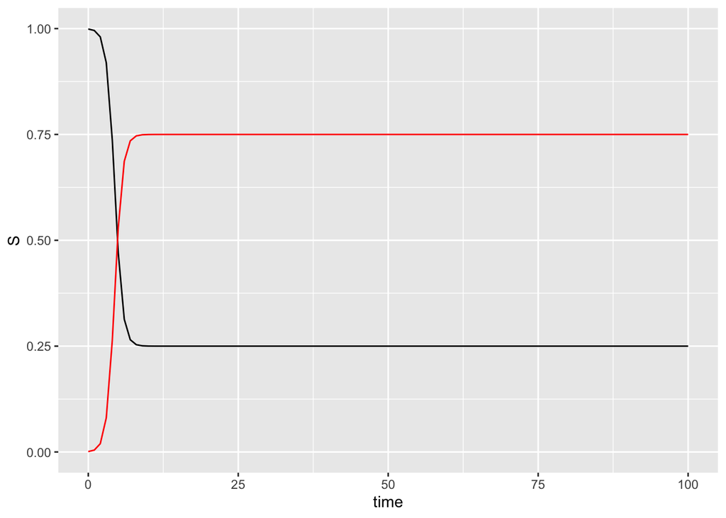

```r
sis_mod <- function(t, state, params){
  # pull listed inputs into environment as names variables
  with(as.list(c(state,params)),{
    # define equations
      dS = -(beta * S * I ) +gamma*I
      dI = (beta*S*I) - gamma*I


      list(c(dS,dI))
  })
}

times = seq(0,100, by=1) #100 days, in discrete units
state = c(S = 0.999, I = 0.001) # initial state values
params = c(beta = 2, gamma = 1/2, N = 1) # parameters

sis_mod_out <- ode(y = state, t = times, func = sis_mod, parms = params) |>
  as_tibble()

sis_mod_out |>
  ggplot(aes(x = time)) +
  geom_line(aes(y = S)) +
  geom_line(aes(y = I),color = "red")
```

# 6 SIRS model - waning immunity

SIR and SIS represent 2 extremes–lifelong immunity (SIR), or lack of immunity (SIS). While these can be realistic for some diseases, an intermediate assumption is waning immunity, where immunity lasts for some period of time before waning. We create a waning rate $\omega$, the rate at which immunity is lost and $R \rightarrow S$. You can imagine that when $\omega = 0$, you get SIR, and when $\omega \rightarrow \infty$, you get SIS.

$\frac{dS}{dt} = \mu +\omega R -\beta SI -\mu S$

$\frac{dI}{dt} = \beta SI - (\gamma+\mu) I$

$\frac{dR}{dt} = \gamma I - \omega R - \mu R$

Similar to before, $R_0 = \beta /(\gamma + \mu)$

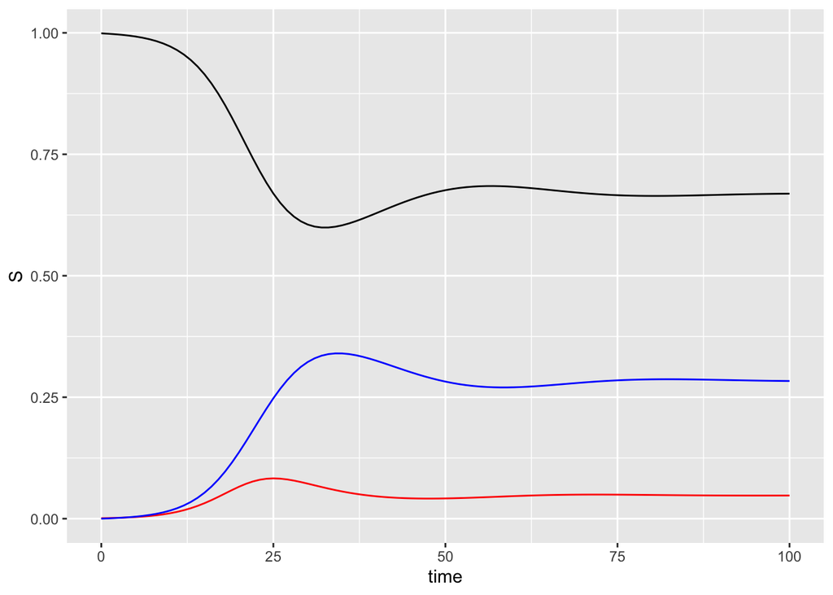

```r
sirs_mod <- function(t, state, params){
  # pull listed inputs into environment as names variables
  with(as.list(c(state,params)),{
    # define equations
      dS = mu +omega * R -(beta * S * I ) -mu*S
      dI = (beta*S*I) - (gamma+mu)*I
      dR = gamma*I - omega*R - mu*R

      list(c(dS,dI,dR))
  })
}

times = seq(0,100, by=1) #100 days, in discrete units
state = c(S = 0.999, I = 0.001, R = 0) # initial state values
params = c(beta = 0.75, gamma = 1/2, N = 1, mu = 1/(70*12), omega = 1/(12*1)) # parameters

sirs_mod_out <- ode(y = state, t = times, func = sirs_mod, parms = params) |>
  as_tibble()

sirs_mod_out |>
  ggplot(aes(x = time)) +
  geom_line(aes(y = S)) +
  geom_line(aes(y = I),color = "red") +
  geom_line(aes(y = R),color = "blue")
```

Similar to the SIR model with birth and death, the equilibrium state is approaches via damped oscillations. I am skipping over the derivation (as K&R do), but the period of oscillations is:

$T = \frac{4\pi}{\sqrt{4(R_0-1)\frac{1}{G_I}\frac{1}{G_r} - (\frac{1}{G_R}-\frac{1}{A})^2}}$

Where A is the average age at first infection, $A=\frac{\omega+\mu+\gamma}{(\omega+\mu)(\beta-\gamma-\mu)}$, and $G_I = \frac{1}{\gamma+\mu}$ is the average period spend infectious and $G_R=\frac{1}{\omega+\mu}$ is the average period spent recovered.

The key thing here is that the rate of immunity waning $\omega$ substantially impacts the dynamics of the disease. As the waning rate increases, the prevalence of the disease increases and the period of the oscillations drops substantially.

(By my math, the formula for $I^{*} = \frac{\mu(\omega+\mu)}{\omega\gamma R_0 - \beta(\omega+\mu)}(1-R_0)$)

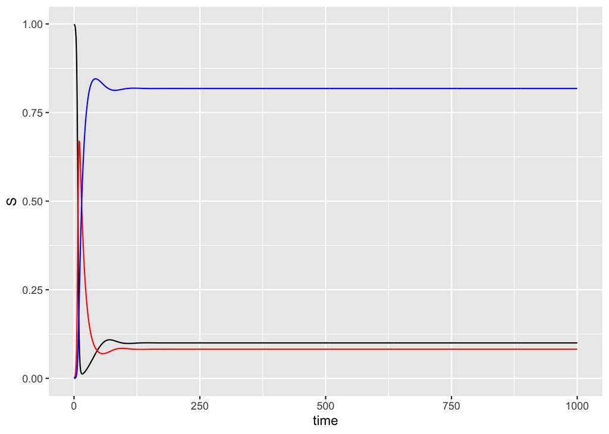

```r
times = seq(0,1000, by=1)
state = c(S = 0.999, I = 0.001, R = 0) # initial state values
params = c(beta = 1.000391, gamma = 1/10, N = 1, mu = 1/(70*365), omega = 0.01) # parameters

sirs_mod_out <- ode(y = state, t = times, func = sirs_mod, parms = params) |>
  as_tibble()

sirs_mod_out |>
  ggplot(aes(x = time)) +
  geom_line(aes(y = S)) +
  geom_line(aes(y = I),color = "red") +
  geom_line(aes(y = R),color = "blue")
```

```r
mu = params["mu"]
gamma = params["gamma"]
beta = params["beta"]
omega = params["omega"]
r0 = beta/(gamma+mu)
I_star = (mu*(omega+mu) / (omega*gamma*r0 - beta*(omega+mu))) * (1-r0)

I_star
```

```
##         mu
## 0.08210919
```

```r
sirs_mod_out$I[nrow(sirs_mod_out)]
```

```
## [1] 0.08210919
```

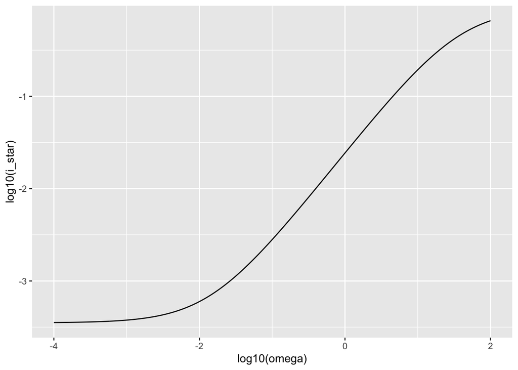

```r
example_df <- expand_grid(r0 = 10,
            mu=1/(70),
            gamma = 1/(10/365),
            omega = 10^seq(-4, 2,length = 1000)) |>
  mutate(beta = r0 * (gamma + mu),
         g_i = 1/(mu+gamma),
         g_r = 1/(omega + mu),
         A = (omega + mu +gamma)/((omega+mu)*(beta - gamma - mu)),
         period = 4*pi / sqrt((4*(r0-1)*(1/g_i)*(1/g_r)) - (((1/g_r)-(1/A))^2)),
         i_star = (mu*(omega+mu) / (omega*gamma*r0 - beta*(omega+mu))) * (1-r0))

example_df |>
  ggplot(aes(x = log10(omega), y = log10(i_star))) +
  geom_line()
```

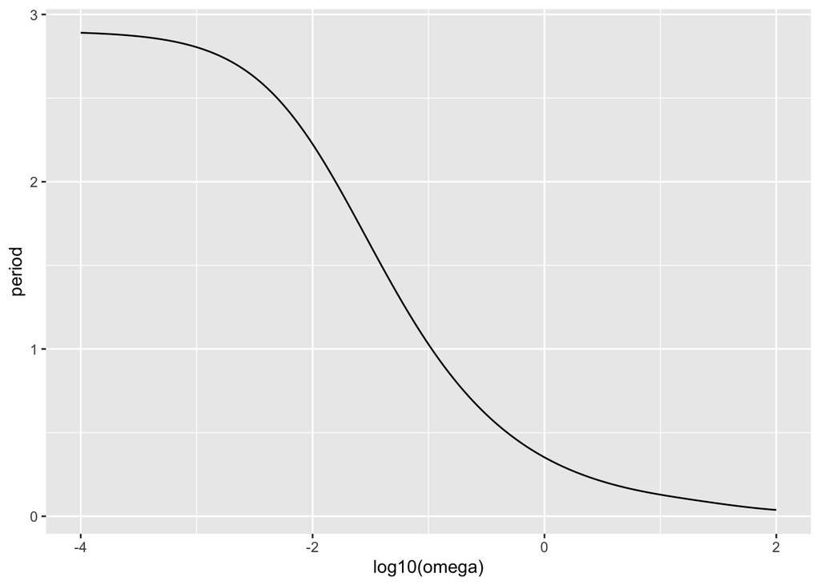

```r
example_df |>
  ggplot(aes(x = log10(omega), y = period)) +
  geom_line()
```

# 7 SEIR model - latent period

The SEIR model adds in a latent period, when individuals are infected (Exposed) but not yet Infectious (I). The model equations are:

$\frac{dS}{dt} = \mu -\beta SI -\mu S$

$\frac{dI}{dt} = \sigma E - (\gamma+\mu) I$

$\frac{dR}{dt} = \gamma I - \mu R$

The latent period (time spent infected but not infectious) is equal to $1/\sigma$.

And assume S + E + I + R = 1 (closed cohort).

This gives

$R_0 = \frac{\beta}{\mu+\gamma} \frac{\sigma}{\mu+\sigma}$

Basically, it’s the same $R_0$ as the SIR model, but some individuals in E die before reaching I, so they do not contribute to transmission. Usually, the second fraction is ~1 (since mu is very small compared to sigma–people’s lifespan (in years) is usually longer than the time spend in latent period (often days or weeks)).

The endemic equilibrium is given by:

$S^{*} = \frac{(\mu +\gamma)(\mu+\sigma)}{\beta\sigma} = \frac{1}{R_0}$

$E^{*} = \frac{\mu(\mu+\gamma)}{\beta\sigma}(R_0 - 1)$

$I^{*} = \frac{\mu}{\beta}(R_0 - 1)$

The equilibrium is again approached via period oscillations, with period $T\approx2\pi\sqrt{AG}$ where $G = \frac{1}{\mu+\gamma} + \frac{1}{\mu+\sigma}$.

“Although the SIR and SEIR models behave similarly at equilibrium (when the parameters are suitably rescaled), the SEIR model has a slower growth rate after pathogen invasion due to individuals needing to pass through the exposed class before they can contribute to the transmission process.”

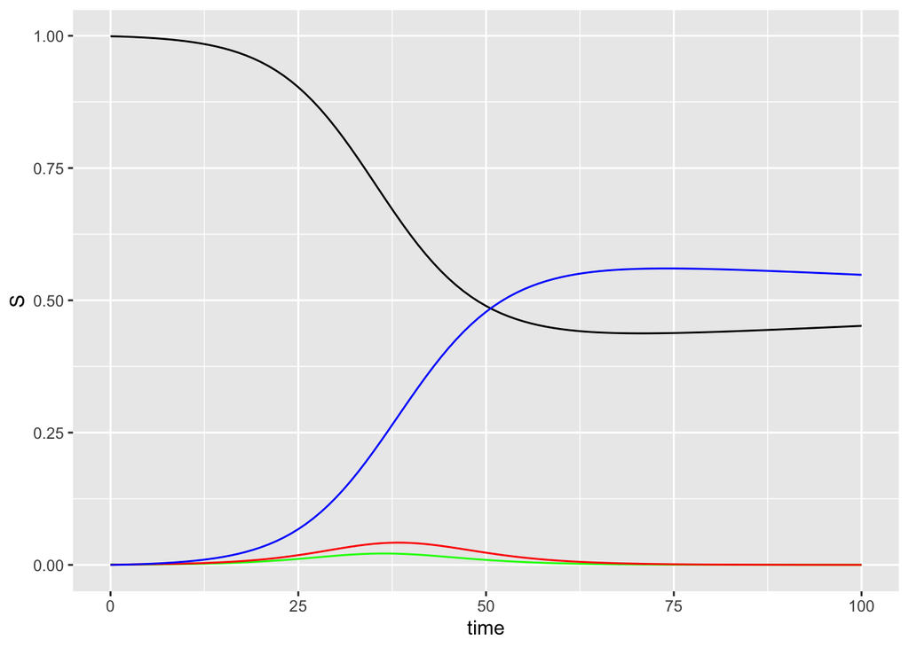

```r
seir_mod <- function(t, state, params){
  # pull listed inputs into environment as names variables
  with(as.list(c(state,params)),{
    # define equations
      dS = mu  -(beta * S * I ) -mu*S
      dE = (beta*S*I) - (mu + sigma)*E
      dI = sigma*E - (gamma+mu)*I
      dR = gamma*I - mu*R

      list(c(dS,dE,dI,dR))
  })
}

times = seq(0,100, by=1) #100 days, in discrete units
state = c(S = 0.999, E=0.001, I = 0, R = 0) # initial state values
params = c(beta = 0.75, gamma = 1/2, N = 1,
           mu = 1/(70*12),sigma = 1/1) # parameters

seir_mod_out <- ode(y = state, t = times, func = seir_mod, parms = params) |>
  as_tibble()

seir_mod_out |>
  ggplot(aes(x = time)) +
  geom_line(aes(y = S)) +
  geom_line(aes(y = E),color = "green") +
  geom_line(aes(y = I),color = "red") +
  geom_line(aes(y = R),color = "blue")
```

# 8 Infections with a carrier state

This is a good point to stop and acknowledge that the general framework we have seen so far for building compartmental models can be readily extended to infections with more complex biology, and can factor in multiple states not addressed so far. One example to try here is a carrier state (like hepatitis B or herpes), where chronic carriers can transmit at a low rate for a long time, even if not acutely infected.

The idea here is that carriers also infect susceptibles, and newly infected people either recover or become carriers after an acute infection period.

The model equations, with C as the carrier state, and $\epsilon$ as the reduced transmission rate and $q$ as the proportion of acute individuals who become carriers vs. $1-q$ who recover, and $\Gamma$ is the rate individuals go from Carrier to Recovered:

$\frac{dS}{dt} = \mu - \beta SI - \epsilon\beta CS - \mu S$

$\frac{dI}{dt} = \beta SI + \epsilon\beta CS - \gamma I -\mu I$

$\frac{dC}{dt} = \gamma qI - \Gamma C- \mu C$

$\frac{dR}{dt} = \gamma(1-q)I +\Gamma C- \mu R$

You can do similar algebra to solve for equilibrium and find $R_0$, which turns out to be

$R_0= \frac{\beta}{\gamma+\mu} + \frac{q\gamma}{(\gamma+\mu)}\frac{\epsilon\beta}{(\Gamma + \mu)}$

The first component of $R_0$ comes from infectious individuals, same as in earlier sections. The added term has 2 parts. The first, $q\gamma / (\gamma+\mu)$ accounts for Infectious individuals who go on to become carriers, and the second accounts for transmission from those carriers.

“The value of R0 is the sum of separate components from the acutely infected and chronic carriers.”

The equilibrium state:

$S^{*} = \frac{\gamma+\mu}{\beta + \frac{q\gamma\epsilon\beta}{\Gamma+\mu}} = \frac{1}{R_0}$

$I^{*} = \frac{\mu(1-S^{*})}{\gamma + \mu}$

$C^{*} = \frac{\gamma q \mu(1-S^{*})}{(\gamma+\mu)(\Gamma+\mu)}$

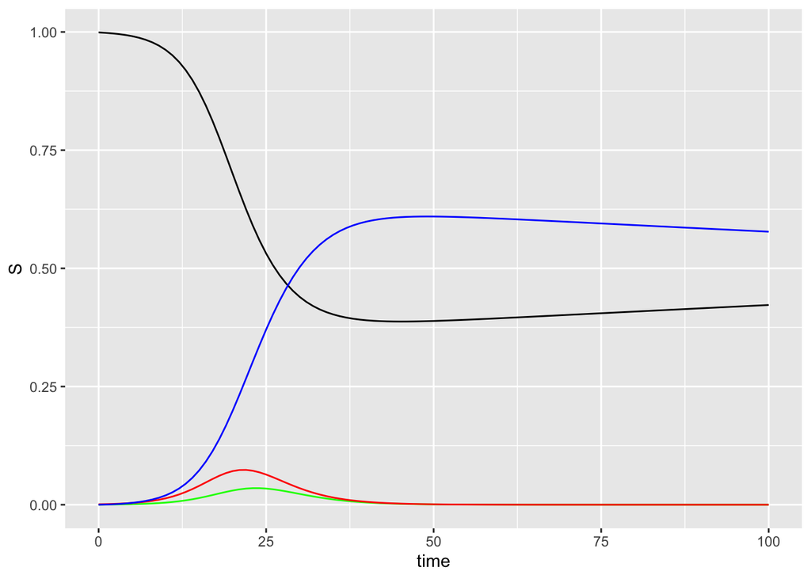

```r
sicr_mod <- function(t, state, params){
  # pull listed inputs into environment as names variables
  with(as.list(c(state,params)),{
    # define equations
      dS = mu  -(beta * S * I) -(epsilon*beta*C*S) -mu*S
      dI = (beta*I + epsilon*beta*C)*S - (gamma+mu)*I
      dC = gamma*q*I - GAMMA *C - mu*C
      dR = gamma*(1-q)*I + GAMMA*C - mu*R

      list(c(dS,dI,dC,dR))
  })
}

times = seq(0,100, by=1) #100 days, in discrete units
state = c(S = 0.999, I = 0.001,C=0, R = 0) # initial state values
params = c(beta = 0.75, gamma = 1/2, N = 1,
           mu = 1/(70*12),q = 0.5, GAMMA = 1/2,
           epsilon = 0.1) # parameters

sicr_mod_out <- ode(y = state, t = times, func = sicr_mod, parms = params) |>
  as_tibble()

sicr_mod_out |>
  ggplot(aes(x = time)) +
  geom_line(aes(y = S)) +
  geom_line(aes(y = C),color = "green") +
  geom_line(aes(y = I),color = "red") +
  geom_line(aes(y = R),color = "blue")
```

# 9 Discrete time models

Up until now, we have dealth with continuous differential equation models. These are convenient mathematically, assume epidemiologically that disease transmission occurs in real time, and assume real time dynamics may be important. However discrete models, assuming transmission probabilities are binomial, are also possible. K&R now introduce these models in a deterministic setting.

One key question is what a given increment of time represents. Ideally it should be in “generation length” of infection through a host, but this is sometimes difficult. Consider a disease with latent and infectious periods of exactly 1 week. We want to now the future change in the fraction in each state at a given time. We now get *difference* equations:

$E_{t+1} = S_t(1-e^{-\beta I_t})$

$I_{t+1} = E_t$

Here, $\mu$ represents *weekly* per capita births. The exponential term represents the per capita probability of *not* contracting the infection given $I_t$ infectives iwth transmission $\beta$. In statistical terms, this assumes transmission probability per susceptible follows a poisson($\beta I_t$) distribution. In this context, $\beta$ is analogous to $R_0$ for the infection.

We solve for equilibrium similarly to before, setting each $S_{t+1} = S_t = S^{*}$:

$S^{*} = \frac{\mu}{1-e^{-\beta \mu}}$

$E^{*} = \mu$

$I^* = \mu$

And we require that the fraction susceptible is less than 1 ($S^{*} <1$, since we need some infectives in the population for the disease to spread). This yields:

$\beta > \frac{-log(1-\mu)}{\mu}$

There are some additional details in the book, concerning equilibrium states and expanding the exponential terms into polynomial terms. However K&R don’t go into extensive detail, and the polynomial approach is somewhat mathematically fragile.

# 10 Parametrizing - estimating parameters

In practice, we need to come up with realistic parameters for our models. For example the SIR model has 4 parameters (birth rate, natural death rate, recovery rate, transmission rate). Ideally we could get all of these from data, but in practice that may not be feasible. Generally birth and death can be estimated from pre-outbreak data, and recovery from looking at infected people only. That leaves the transmission rate, which can be calculated by measuring $R_0$ in the population.

## 10.1 Estimating $R_0$ from reported cases

A naive approach might be to record the total number of reported cases in a given community/area. However, recall from the SIR model that:

$I^{*} = \frac{\mu}{\gamma + \mu}(1-\frac{1}{R_0}) = \frac{\mu}{\beta}(R_0 -1)$

If $R_0$ is much larger than 1, the effect of $R_0$ on prevalence will be relatively small. Also, some cases will go unreported.

An alternative approach is to focus on the early epidemic behavior, which follows an exponential distribution:

$I(t) \sim I(0) exp([R_0 - 1](\gamma + \mu)t)$

Some caveats:

1. This only works if there is an epidemic; not for endemic diseases
2. In the early stages of an epidemic, dynamics will be very random and may have large fluctuations.
3. Unless it is a new pathogen, some people will actually be immune

To introduce some more terminology that will be useful, we have until now been thinking of Y(t), the prevalence at time t. However when it comes to estimating new cases, it’s better to have K(T), the number of new cases reported at time point T:

$K(T) = \int_{T-1}^T{\gamma I dt}$

Finally, a powerful approach is to use case reports to identify the average age at infection in an endemic situation. Since we have the equation that $A \approx 1/(\mu(R_0 - 1))$ when $R_0$ is large, we can use this to find $R_0$. The average age at infection is usually estimated as the average age of reported cases. This works very well in practice. Two limitations are:

1. The age of patients may not always be recorded, so may be a challenge with historical data
2. Which individual infections are reported may be biased, so age-related reporting biases may influence results.

## 10.2 Estimating $R_0$ from seroprevalence data

Case reporting is problematic in humans because reporting can be patchy, biased, and not everyone seeks medical care. This problem is even worse for wildlife diseases. Molucular techniques can help overcome this, since we can randomly sample the population and see who was or was not infected. The limitation here is that collecting this data may be expensive and time consuming relative to routine surveillance.

The simplest approach is to assume $S = 1/R_0$. So we just care about the proportion that are seronegative. The problem is that we need to make sure it’s a representative sample of the whole population, especially since seroprevalence tends to increase with age.

Another approach is to use the age-dependent nature of susceptibility to our advantage. Basically this involves finding the propbability an individual is susceptible at age a as $P(a) \approx exp(-a\mu(R_0 - 1))$. Then we find the $R_0$ value that maximizes the likelihood of this distribution. If a is seronegative and b is seropositive, we have:

$L(R_0) = \Pi_{i=1}^n exp(-a_i \mu (R_0-1))\Pi_{i=1}^m [1-exp(-b_i\mu(R_0-1))]$

Using this approach, we would want to preferentially sample from people whose age of infection we expect to be close to the average.

## 10.3 Estimating parameters in general

The likelihood framework above can be generalized to other parameters. Ideally, we want as much data from idividual observations as possible, but this still doesn’t always work for transmission characteristics. In such cases, maximum likelihood estimation is the best bet (NB: bayesian techniques may also work well here).

We will return to the issue fo parameterization in another chapter.